# Proyecto N°2

Marlon Alejandro Quisaguano Acosta

2023-06-15

## Objetivos

- 1. Aplicar Estadística Descriptiva
- 2. Aplicar Estadística Inferencial
- 3. Generar nuevas variables y/o drivers
- 4. Realizar el análisis exploratorio de datos (EDA)
- 5. Generar nuevas variables de valor.
- 6. Realizar la segmentación (k= 3, 4 ó 5)
- 7. Desarrollar un modelo logístico; considerar como variable independiente la variable Segmentación
- 8. Interpretar el ajuste del modelo

# 1. Lectura y Limpiez de Datos

### Lectura de Datos

En esta sección importaremos la información de interés. Para esto primero nos dirigimos a la dirección de la base de datos mediante la función ´setwd()´, en la cual se debe introducir la dirección del archivo compartido “Caso. Data_Nutrición”, sin olvidar reemplazar el “/”. También se hace uso del paquete “readxl” para la lectura del archivo .xlsx.

```r
setwd("C:/Users/marlo/OneDrive/Documentos/CURSO DE DATA SCIENTIST/Proyecto 2/")
data_Nutricion <- readxl::read_xlsx("Caso. Data_Nutricion.xlsx",sheet = "Data")
```

Observemos las primeras 5 filas y 5 variables de los datos importados:

```r
head(data_Nutricion[,c(1:5)],n = 5)
```

```
## # A tibble: 5 × 5
##    `N°` Individuo sexo  talla  edad
##   <dbl> <chr>     <chr> <dbl> <dbl>
## 1     1 Persona 1 F      156.    16
## 2     2 Persona 2 F      166.    16
## 3     3 Persona 3 F      151.    16
## 4     4 Persona 4 F      152.    16
## 5     5 Persona 5 F      160.    16
```

A demás, podemos observar que existen 652 filas (registros de clientes) y 23 variables descriptivas (columnas que describen a cada individuo)

```r
dim(data_Nutricion)
```

```
## [1] 652  23
```

estas variables o columnas describen a cada indiciduo de la siguiente manera:

```r
str(data_Nutricion)
```

```
## tibble [652 × 23] (S3: tbl_df/tbl/data.frame)
##  $ N°                         : num [1:652] 1 2 3 4 5 6 7 8 9 10 ...
##  $ Individuo                  : chr [1:652] "Persona 1" "Persona 2" "Persona 3" "Persona 4" ...
##  $ sexo                       : chr [1:652] "F" "F" "F" "F" ...
##  $ talla                      : num [1:652] 156 166 151 152 160 ...
##  $ edad                       : num [1:652] 16 16 16 16 16 16 16 16 16 16 ...
##  $ peso_kg                    : chr [1:652] "71.2" "61" "49.1" "54.6" ...
##  $ circun_cuello              : num [1:652] 35.7 31.8 30.5 32.6 30.1 33.9 30.5 31.2 37.5 30.8 ...
##  $ IMC                        : num [1:652] 29.6 22.4 21.6 23.1 22.3 ...
##  $ circun_cintura             : num [1:652] 90 80.9 72 74.4 79.6 ...
##  $ cadera                     : chr [1:652] "98" "100.5" "86" "88.4" ...
##  $ ind_cintura_cadera         : num [1:652] 0.918 0.805 0.837 0.842 0.813 ...
##  $ ind_cintura_estatura       : num [1:652] 0.578 0.486 0.476 0.49 0.497 ...
##  $ por_grasa_corporal         : num [1:652] 36.4 28.8 29.9 27.9 30.3 ...
##  $ masa_corporal_magra_kg     : num [1:652] 45.3 43.4 34.4 39.4 40.4 ...
##  $ pliegue_cutaneo_BICEPS     : chr [1:652] "13" "5" "13" "5" ...
##  $ pliegue_cutaneo_TRICEPS    : chr [1:652] "27" "19" "18" "19" ...
##  $ pliegue_cutaneo_ESCAPULAR  : chr [1:652] "32" "15" "18" "15" ...
##  $ pliegue_cutaneo_SUPRAILIACO: chr [1:652] "34" "22" "17" "18" ...
##  $ clasif_diagnos_talla_edad  : chr [1:652] "RIESGO DE TALLA BAJA" "TALLA NORMAL" "RIESGO DE TALLA BAJA" "RIESGO DE TALLA BAJA" ...
##  $ clasif_diagnos_IMC         : chr [1:652] "OBESIDAD" "NORMAL" "NORMAL" "NORMAL" ...
##  $ clasif_perimetro_abdominal : chr [1:652] "ALTO RIESGO" "BAJO RIESGO" "BAJO RIESGO" "BAJO RIESGO" ...
##  $ clasif_anemia              : chr [1:652] "NO PRESENTA ANEMIA" "NO PRESENTA ANEMIA" "ANEMIA LEVE" "NO PRESENTA ANEMIA" ...
##  $ target                     : num [1:652] 1 0 0 0 1 0 1 0 1 0 ...
```

- N° y Individuo: Codifica o identifica al individuo, funciona como número DNI de cada cliente. (Puede considerarse como una variable numérica exclusiva para cada individuo o caracter que lo idetifica).
- Sexo: Claifica al individuo entre (M)masculino y (F)femenino (Factor).
- Edad, Talla, peso_kg, circun_cuello, IMC, circun_cintura, cadera, ind_cintura_cadera, ind_cintura_estatura, por_grasa_corporal, masa_corporal_magra_kg, pliegue_cutaneo_BICEPS, pliegue_cutaneo_TRICEPS, pliegue_cutaneo_ESCAPULAR, pliegue_cutaneo_SUPRAILIACO: Las variables de la base de datos describen distintos aspectos relacionados con la composición corporal y características físicas de una persona. (Variable numéricas: integer o double).
- clasif_diagnos_talla_edad, clasif_diagnos_IMC, clasif_perimetro_abdominal, clasif_anemia : Categoriza al individuo en niveles categóricos deacuerdo a la talla, edad, índice de masa corporal, perímetro adominal, anemia. (Variable categórica-factor).
- target: Identifica a la variable objetivo (Tiene diabetes 1 / No tiene diabetes 0). (Variable integer). Cabe recalcar que puede ser tratada como una bariable binomial y hasta que sea necesario se tratará como una bariable categórica.

Como podemos observar, a continuación:

```r
sum(is.na(data_Nutricion))
```

```
## [1] 155
```

entre nuestras variables existen datos nulos o perdidos, por lo que es necesario realizar un análisis por variable para determinar cual de ellas debe ser tratada. Por lo tanto, en la siguiente sección procederemos a estructurar, limpiar y analizar nuestra base de datos.

### Estructura y limpieza de datos.

Primeramente procedemos a cambiar el tipo de cada una de las vriables, para esto hacemos uso de las descripciones de cada una de las variables mencionadas en la sección anterior, y del paquete “dplyr” para la manipulación:

- N° y Individuo: (character).
- Sexo: (character - factor).
- Edad, Talla, peso_kg, circun_cuello, IMC, circun_cintura, cadera, ind_cintura_cadera, ind_cintura_estatura, por_grasa_corporal, masa_corporal_magra_kg, pliegue_cutaneo_BICEPS, pliegue_cutaneo_TRICEPS, pliegue_cutaneo_ESCAPULAR, pliegue_cutaneo_SUPRAILIACO (numerics: integers o doubles).
- clasif_diagnos_talla_edad, clasif_diagnos_IMC, clasif_perimetro_abdominal, clasif_anemia : (character-factor).
- target: (character-factor).

```r
data_Nutricion <- data_Nutricion %>%
  mutate(`N°`  = as.character(`N°`),
         Individuo = as.character(Individuo),
         sexo  = as.factor(sexo),
         talla = as.double(talla),
         edad = as.integer(edad),
         peso_kg = as.double(peso_kg),
         circun_cuello = as.double(circun_cuello),
         IMC = as.double(IMC),
         circun_cintura = as.double(circun_cintura),
         cadera = as.double(cadera),
         ind_cintura_cadera = as.double(ind_cintura_cadera),
         ind_cintura_estatura = as.double(ind_cintura_estatura),
         por_grasa_corporal = as.double(por_grasa_corporal),
         masa_corporal_magra_kg = as.double(masa_corporal_magra_kg),
         pliegue_cutaneo_BICEPS = as.double(pliegue_cutaneo_BICEPS),
         pliegue_cutaneo_TRICEPS = as.double(pliegue_cutaneo_TRICEPS),
         pliegue_cutaneo_ESCAPULAR = as.double(pliegue_cutaneo_ESCAPULAR),
         pliegue_cutaneo_SUPRAILIACO = as.double(pliegue_cutaneo_SUPRAILIACO),
         clasif_diagnos_talla_edad = as.factor(clasif_diagnos_talla_edad),
         clasif_diagnos_IMC = as.factor(clasif_diagnos_IMC),
         clasif_perimetro_abdominal = as.factor(clasif_perimetro_abdominal),
         clasif_anemia = as.factor(clasif_anemia),
         target = as.factor(target)

         )
```

Ahora generamos una función para poder conocer los valores para cada una de las variables si existe la presencia de valores perdidos:

```r
naniar <- function(data)
{
  variables_perdidas <- data %>%
  select_if(function(x)  anyNA(x))

 valores_perdidos <- data.frame(variable = names(variables_perdidas),
                               valores_perdidos = sapply(variables_perdidas, function(x) sum(is.na(x))),
                               porcentaje_perdidos = round(sapply(variables_perdidas, function(x) mean(is.na(x)))*100,2))

  valores_perdidos<-valores_perdidos %>% dplyr::arrange(desc(valores_perdidos))
  return(valores_perdidos)
}
a<-naniar(data_Nutricion)
a
```

```
##                                                variable valores_perdidos
## sexo                                               sexo               25
## talla                                             talla               17
## masa_corporal_magra_kg           masa_corporal_magra_kg               14
## clasif_diagnos_IMC                   clasif_diagnos_IMC               13
## circun_cintura                           circun_cintura               11
## ind_cintura_cadera                   ind_cintura_cadera               11
## pliegue_cutaneo_TRICEPS         pliegue_cutaneo_TRICEPS                8
## clasif_anemia                             clasif_anemia                8
## circun_cuello                             circun_cuello                7
## pliegue_cutaneo_ESCAPULAR     pliegue_cutaneo_ESCAPULAR                6
## clasif_diagnos_talla_edad     clasif_diagnos_talla_edad                6
## peso_kg                                         peso_kg                5
## pliegue_cutaneo_BICEPS           pliegue_cutaneo_BICEPS                5
## clasif_perimetro_abdominal   clasif_perimetro_abdominal                5
## ind_cintura_estatura               ind_cintura_estatura                4
## por_grasa_corporal                   por_grasa_corporal                3
## edad                                               edad                2
## cadera                                           cadera                2
## pliegue_cutaneo_SUPRAILIACO pliegue_cutaneo_SUPRAILIACO                2
## IMC                                                 IMC                1
##                             porcentaje_perdidos
## sexo                                       3.83
## talla                                      2.61
## masa_corporal_magra_kg                     2.15
## clasif_diagnos_IMC                         1.99
## circun_cintura                             1.69
## ind_cintura_cadera                         1.69
## pliegue_cutaneo_TRICEPS                    1.23
## clasif_anemia                              1.23
## circun_cuello                              1.07
## pliegue_cutaneo_ESCAPULAR                  0.92
## clasif_diagnos_talla_edad                  0.92
## peso_kg                                    0.77
## pliegue_cutaneo_BICEPS                     0.77
## clasif_perimetro_abdominal                 0.77
## ind_cintura_estatura                       0.61
## por_grasa_corporal                         0.46
## edad                                       0.31
## cadera                                     0.31
## pliegue_cutaneo_SUPRAILIACO                0.31
## IMC                                        0.15
```

Entonces, como podemos observar entre las variables de interés, sexo tiene el mayor porcentaje de valores perdidos (3.83%) de todas las variables. De esta manera, en la siguiente sección nos encargaremos de analizar a cada una de estas variables con el objetivo de imputar los valores faltantes.

### Análisis de Valores faltantes

Existen diversas formas de imputar valores faltantes, entre las formas mas sencillas está hacer uso de medidas de tendencia central como el promedio, media o mediana. En la siguiente sección utilizaremos una de estas medidas para realizar la imputación. Cabe señalar que una mejor imputación puede generarse al realizar utilizando un modelo de regresión en la cual se tome en cuenta la información de otra variable, es decir utilizar la información asociada al valor nulo para completar con mejor coherencia el valor perdido o atípico.

## Imputación de datos Perdidos o atípicos.

Primero identificaremos los datos perdidos o a típicos para lo cual primero realizaremos una prueba de estadística para saber si la variable sigue una distribución normal o no. Esto con el objetivo de poder escoger los límites para determinar si un valor es a típico o no.

Primero tratemos los datos faltantes o perdidos, determinemos que variables tienen valores faltantes:

```r
variables_con_valores_perdidos <- function(data) {
  missing_vars <- colnames(data)[apply(data, 2, function(x) any(is.na(x)))]
  return(missing_vars)
}
variables_perdidos <- variables_con_valores_perdidos(data_Nutricion)
variables_perdidos
```

```
##  [1] "sexo"                        "talla"
##  [3] "edad"                        "peso_kg"
##  [5] "circun_cuello"               "IMC"
##  [7] "circun_cintura"              "cadera"
##  [9] "ind_cintura_cadera"          "ind_cintura_estatura"
## [11] "por_grasa_corporal"          "masa_corporal_magra_kg"
## [13] "pliegue_cutaneo_BICEPS"      "pliegue_cutaneo_TRICEPS"
## [15] "pliegue_cutaneo_ESCAPULAR"   "pliegue_cutaneo_SUPRAILIACO"
## [17] "clasif_diagnos_talla_edad"   "clasif_diagnos_IMC"
## [19] "clasif_perimetro_abdominal"  "clasif_anemia"
```

Ya hemos almacenado las variables con valores faltantes o perdidos, entonces generaremos una función que reemplace los datos perdidos por la media de la misma:

```r
reemplazar_valores_faltantes <- function(data, variables_perdidas) {
  for (variable in variables_perdidas) {
    if (is.numeric(data[[variable]])) {
      media <- mean(data[[variable]], na.rm = TRUE)
      data[[variable]][is.na(data[[variable]])] <- media
    } else if (is.character(data[[variable]]) || is.factor(data[[variable]])) {
      moda <- as.character(mlv(as.character(data[[variable]]),na.rm=TRUE))
      data[[variable]][is.na(data[[variable]])] <- moda
      data[[variable]] <- factor(data[[variable]]) # Convertir de nuevo a factor
    }
  }

  return(data)
}
data_Nutricion <- reemplazar_valores_faltantes(data_Nutricion,variables_perdidos)
```

Ahora verifiquemos que no existe ningún dato perdido en la base procesada:

```r
sum(is.na(data_Nutricion))
```

```
## [1] 0
```

Como podemos observar, tenemos 0 valores perdidos en la base procesada.

Ahora realicemos pruebas de normalidad a las variables ya que pretendemos realizar un análisis de valores atípicos. Esto para poder determinar el límite correcto de cada variable según su comportamiento.

```r
data <- data_Nutricion
str(data)
```

```
## tibble [652 × 23] (S3: tbl_df/tbl/data.frame)
##  $ N°                         : chr [1:652] "1" "2" "3" "4" ...
##  $ Individuo                  : chr [1:652] "Persona 1" "Persona 2" "Persona 3" "Persona 4" ...
##  $ sexo                       : Factor w/ 2 levels "F","M": 1 1 1 1 1 1 2 2 1 2 ...
##  $ talla                      : num [1:652] 156 166 151 152 160 ...
##  $ edad                       : num [1:652] 16 16 16 16 16 16 16 16 16 16 ...
##  $ peso_kg                    : num [1:652] 71.2 61 49.1 54.6 58 70.8 47.4 49.3 91 50.4 ...
##  $ circun_cuello              : num [1:652] 35.7 31.8 30.5 32.6 30.1 33.9 30.5 31.2 37.5 30.8 ...
##  $ IMC                        : num [1:652] 29.6 22.4 21.6 23.1 22.3 ...
##  $ circun_cintura             : num [1:652] 90 80.9 72 74.4 79.6 ...
##  $ cadera                     : num [1:652] 98 100.5 86 88.4 97.9 ...
##  $ ind_cintura_cadera         : num [1:652] 0.918 0.805 0.837 0.842 0.813 ...
##  $ ind_cintura_estatura       : num [1:652] 0.578 0.486 0.476 0.49 0.497 ...
##  $ por_grasa_corporal         : num [1:652] 36.4 28.8 29.9 27.9 30.3 ...
##  $ masa_corporal_magra_kg     : num [1:652] 45.3 43.4 34.4 39.4 40.4 ...
##  $ pliegue_cutaneo_BICEPS     : num [1:652] 13 5 13 5 10 11 3.5 5.5 25 3 ...
##  $ pliegue_cutaneo_TRICEPS    : num [1:652] 27 19 18 19 19 25 7 12 21 7 ...
##  $ pliegue_cutaneo_ESCAPULAR  : num [1:652] 32 15 18 15 20 18 6 10.5 25 8.5 ...
##  $ pliegue_cutaneo_SUPRAILIACO: num [1:652] 34 22 17 18 19 ...
##  $ clasif_diagnos_talla_edad  : Factor w/ 4 levels "RIESGO DE TALLA BAJA",..: 1 4 1 1 4 4 1 1 4 4 ...
##  $ clasif_diagnos_IMC         : Factor w/ 5 levels "DELGADEZ","NORMAL",..: 3 2 2 2 2 5 4 2 3 4 ...
##  $ clasif_perimetro_abdominal : Factor w/ 2 levels "ALTO RIESGO",..: 1 2 2 2 2 1 2 2 1 2 ...
##  $ clasif_anemia              : Factor w/ 4 levels "ANEMIA LEVE",..: 3 3 1 3 3 3 3 3 3 3 ...
##  $ target                     : Factor w/ 2 levels "0","1": 2 1 1 1 2 1 2 1 2 1 ...
```

```r
prueba_normalidad <- function(data) {
  resultados <- data.frame(Variable = character(), Normal = logical(), Numerica = logical(), stringsAsFactors = FALSE)

  for (variable in colnames(data)) {
    if (is.numeric(data[[variable]]) || is.double(data[[variable]])) {
      resultado <- nortest::ad.test(data[[variable]])
      normal <- !resultado$p.value < 0.05

      resultados <- rbind(resultados, data.frame(Variable = variable, Normal = normal, Numerica = TRUE, stringsAsFactors = FALSE))
    } else {
      normal <- NA

      resultados <- rbind(resultados, data.frame(Variable = variable, Normal = normal, Numerica = FALSE, stringsAsFactors = FALSE))
    }
  }

  return(resultados)
}


variables_normales <- prueba_normalidad(data_Nutricion)
variables_normales
```

```
##                       Variable Normal Numerica
## 1                           N°     NA    FALSE
## 2                    Individuo     NA    FALSE
## 3                         sexo     NA    FALSE
## 4                        talla  FALSE     TRUE
## 5                         edad  FALSE     TRUE
## 6                      peso_kg  FALSE     TRUE
## 7                circun_cuello  FALSE     TRUE
## 8                          IMC  FALSE     TRUE
## 9               circun_cintura  FALSE     TRUE
## 10                      cadera  FALSE     TRUE
## 11          ind_cintura_cadera   TRUE     TRUE
## 12        ind_cintura_estatura  FALSE     TRUE
## 13          por_grasa_corporal  FALSE     TRUE
## 14      masa_corporal_magra_kg  FALSE     TRUE
## 15      pliegue_cutaneo_BICEPS  FALSE     TRUE
## 16     pliegue_cutaneo_TRICEPS  FALSE     TRUE
## 17   pliegue_cutaneo_ESCAPULAR  FALSE     TRUE
## 18 pliegue_cutaneo_SUPRAILIACO  FALSE     TRUE
## 19   clasif_diagnos_talla_edad     NA    FALSE
## 20          clasif_diagnos_IMC     NA    FALSE
## 21  clasif_perimetro_abdominal     NA    FALSE
## 22               clasif_anemia     NA    FALSE
## 23                      target     NA    FALSE
```

De esta manera, definimos el siguiente código:

```r
data <- data_Nutricion
imputar_outliers <- function(data,variables_normales, z_score_limite = 3, percentil_alto = 95, percentil_bajo = 5) {
  variables_normales <- variables_normales %>% dplyr::filter(Numerica==TRUE)
  for (i in 1:dim(variables_normales)[1] ) {# i<-2

    variable <- variables_normales[i, "Variable"]
    normal <- variables_normales[i, "Normal"]

    if (normal) {
      outliers <- boxplot.stats(data[[variable]])$out
    }else {
      z_scores <- abs(scale(data[[variable]]))
      outliers <- data[[variable]][z_scores > z_score_limite]
    }

    if (length(outliers) > 0) {
      data[[variable]][data[[variable]] %in% outliers] <- mean(data[[variable]], na.rm = TRUE)
    }
  }

  return(data)
}

data_imputada_Nutricion <- imputar_outliers(data_Nutricion,variables_normales)
```

De esta manera, en el siguiente capítulo podemos avanzar con estadística descriptiva.

### Estadística descriptiva

Ahora podemos empezar a realizar un análisis descriptivo de las variables, para lo cual implementamos una función que nos muestra información general de las variables.

```r
Medidas_disp <- function(data)
{

 variables_numericas <- data %>%
  select_if(function(x) is.numeric(x))


  medidas_de_dispersion <- data.frame(
    Rango = sapply(variables_numericas,function(x) (round(max(x) - min(x), 2)) ),
    Mininmo = sapply(variables_numericas, function(x) min(x)),
    Percentil25 = sapply(variables_numericas,function(x) quantile(x,.25) ),
    Percentil50 = sapply(variables_numericas,function(x) quantile(x,.50)),
    Percentil75 = sapply(variables_numericas,function(x) quantile(x,.75)),
    Percentil90 = sapply(variables_numericas,function(x) quantile(x,.90)),
    Maximo = sapply(variables_numericas, function(x) max(x)),
    Rango_intercuantilico = sapply(variables_numericas,function(x)  (quantile(x,.75) - quantile(x,.25))),
    Varianza = sapply(variables_numericas,function(x) round(var(x),2) ),
    Desv.estand  = sapply(variables_numericas,function(x) round(sd(x),2)),
    Coef.var = sapply(variables_numericas,function(x) round(sd(x) /mean(x) * 100,2) ),
    Kurtosis = sapply(variables_numericas,function(x) round(kurtosis(x),5) )
  )

return(medidas_de_dispersion)
}

Med_Disp <- Medidas_disp(data_imputada_Nutricion)
Med_Disp
```

```
##                             Rango     Mininmo Percentil25 Percentil50
## talla                       38.40 141.5000000 153.8000000 158.6500000
## edad                         5.00  12.0000000  14.0000000  15.0000000
## peso_kg                     48.40  33.9000000  51.1000000  55.9500000
## circun_cuello               10.80  27.7000000  30.7000000  32.0000000
## IMC                         16.14  14.5378862  20.2781434  22.1812765
## circun_cintura              40.00  55.0000000  70.0000000  74.0000000
## cadera                      40.50  69.8000000  85.0000000  89.0000000
## ind_cintura_cadera           0.28   0.6920530   0.7952978   0.8292683
## ind_cintura_estatura         0.23   0.3623188   0.4393005   0.4654479
## por_grasa_corporal          35.23   4.2143103  16.1278031  26.0713746
## masa_corporal_magra_kg      34.09  28.4980896  38.3132882  42.4685340
## pliegue_cutaneo_BICEPS      24.00   2.0000000   5.0000000   8.0000000
## pliegue_cutaneo_TRICEPS     27.00   5.0000000  11.0000000  15.6661491
## pliegue_cutaneo_ESCAPULAR   25.00   5.0000000  10.0000000  14.0000000
## pliegue_cutaneo_SUPRAILIACO 29.00   3.0000000  10.0000000  14.6584615
##                             Percentil75 Percentil90      Maximo
## talla                       163.3000000 168.6800000 179.9000000
## edad                         15.0000000  16.0000000  17.0000000
## peso_kg                      61.4000000  66.8000000  82.3000000
## circun_cuello                33.5000000  34.9900000  38.5000000
## IMC                          23.7660072  26.1612986  30.6784043
## circun_cintura               78.0000000  83.0000000  95.0000000
## cadera                       93.6500000  98.8000000 110.3000000
## ind_cintura_cadera            0.8644403   0.8957002   0.9729730
## ind_cintura_estatura          0.4930490   0.5262483   0.5969231
## por_grasa_corporal           30.0734933  32.3428964  39.4452825
## masa_corporal_magra_kg       47.9046523  52.3606097  62.5855182
## pliegue_cutaneo_BICEPS       12.0000000  16.0000000  26.0000000
## pliegue_cutaneo_TRICEPS      19.0000000  23.0000000  32.0000000
## pliegue_cutaneo_ESCAPULAR    17.0000000  20.0000000  30.0000000
## pliegue_cutaneo_SUPRAILIACO  19.0000000  22.0000000  32.0000000
##                             Rango_intercuantilico Varianza Desv.estand Coef.var
## talla                                  9.50000000    50.54        7.11     4.48
## edad                                   1.00000000     0.77        0.88     5.93
## peso_kg                               10.30000000    60.43        7.77    13.73
## circun_cuello                          2.80000000     4.39        2.09     6.52
## IMC                                    3.48786385     7.65        2.77    12.41
## circun_cintura                         8.00000000    41.06        6.41     8.62
## cadera                                 8.65000000    45.79        6.77     7.55
```

[output cut: 9 more lines]

```
## talla                       -0.29941
## edad                        -0.63513
## peso_kg                      0.20492
## circun_cuello               -0.16905
## IMC                          0.19355
## circun_cintura               0.19688
## cadera                       0.37405
## ind_cintura_cadera          -0.19380
## ind_cintura_estatura         0.15258
## por_grasa_corporal          -1.11562
## masa_corporal_magra_kg      -0.41295
## pliegue_cutaneo_BICEPS      -0.17590
## pliegue_cutaneo_TRICEPS     -0.37012
## pliegue_cutaneo_ESCAPULAR   -0.12692
## pliegue_cutaneo_SUPRAILIACO -0.60413
```

A partir del resúmen generado podemos aseverar lo siguiente acerca de la población en estudio: * Aproximadamente, el 25% (1.450) de las personas tienen entre 12 a 14 años, teniendo una gran cantidad de personas que se encuentran entre los 14 y 15 años 50%.

- Podemos observar también que más del 50% tiene una estatura menor a 160 cm y solo un 10% alcanza el metro setenta.
- Encontramos el primer dato relevante, ya que apesar de tener una población relativamente joven y de talla baja, podemos identificar que tienen un peso alto ya que el 50 % de la población se encuentra por encima del 55 kg.

Y de la misma manera podemos generar medidas de tendencia central:

```r
Tendencia_central <- function(data)
{

 variables_numericas <- data %>%
  select_if(function(x) is.numeric(x))

 tendencia_central <- data.frame(variable = names(variables_numericas),
                                mediana = sapply(variables_numericas, function(x) median(x)),
                                media = sapply(variables_numericas, function(x) mean(x)),
                                moda = sapply(variables_numericas, function(x) mlv(x, na.rm = TRUE)),
  centro_de_amplitud = sapply(variables_numericas, function(x) (min(x) + max(x))/2),
  media_geometrica = sapply(variables_numericas,function(x) (exp(sum(log(x))/length(x)) )),
  media_armonica = sapply(variables_numericas,function(x) ( round(1/mean(1/x), 2) )),
  media_recortada_10_porc = sapply(variables_numericas,function(x) round(mean(x,trim=10/100), 2)),
  timedia = sapply( variables_numericas ,function(x) round((quantile(x,.25, na.rm = TRUE) + 2*quantile(x,.50, na.rm = TRUE) + quantile(x,.75, na.rm = TRUE))/4, 2))

  )

return(tendencia_central)

}
tend_central <- Tendencia_central(data_imputada_Nutricion)
tend_central
```

```
##                                                variable     mediana       media
## talla                                             talla 158.6500000 158.7548094
## edad                                               edad  15.0000000  14.7857197
## peso_kg                                         peso_kg  55.9500000  56.6037860
## circun_cuello                             circun_cuello  32.0000000  32.1524849
## IMC                                                 IMC  22.1812765  22.2969538
## circun_cintura                           circun_cintura  74.0000000  74.3787133
## cadera                                           cadera  89.0000000  89.6426805
## ind_cintura_cadera                   ind_cintura_cadera   0.8292683   0.8297152
## ind_cintura_estatura               ind_cintura_estatura   0.4654479   0.4692174
## por_grasa_corporal                   por_grasa_corporal  26.0713746  23.5021811
## masa_corporal_magra_kg           masa_corporal_magra_kg  42.4685340  43.2464395
## pliegue_cutaneo_BICEPS           pliegue_cutaneo_BICEPS   8.0000000   9.0638447
## pliegue_cutaneo_TRICEPS         pliegue_cutaneo_TRICEPS  15.6661491  15.5991741
## pliegue_cutaneo_ESCAPULAR     pliegue_cutaneo_ESCAPULAR  14.0000000  14.1741201
## pliegue_cutaneo_SUPRAILIACO pliegue_cutaneo_SUPRAILIACO  14.6584615  14.5679330
##                                    moda centro_de_amplitud media_geometrica
## talla                       157.5626863         160.700000      158.5966843
## edad                         14.6051817          14.500000       14.7597857
## peso_kg                      53.5357929          58.100000       56.0809700
## circun_cuello                31.6850312          33.100000       32.0851285
## IMC                          21.6372925          22.608145       22.1292483
## circun_cintura               73.2466904          75.000000       74.1085548
## cadera                       88.1169561          90.050000       89.3912303
## ind_cintura_cadera            0.8237396           0.832513        0.8281507
## ind_cintura_estatura          0.4616181           0.479621        0.4673289
## por_grasa_corporal           29.6641428          21.829796       21.8890513
## masa_corporal_magra_kg       39.3230562          45.541804       42.7559532
## pliegue_cutaneo_BICEPS        5.7776074          14.000000        7.9126811
## pliegue_cutaneo_TRICEPS      16.4008021          18.500000       14.5379383
## pliegue_cutaneo_ESCAPULAR    12.3651114          17.500000       13.3318936
## pliegue_cutaneo_SUPRAILIACO  14.6665408          17.500000       13.2961126
##                             media_armonica media_recortada_10_porc timedia
## talla                               158.44                  158.57  158.60
## edad                                 14.73                   14.77   14.75
## peso_kg                              55.57                   56.20   56.10
## circun_cuello                        32.02                   32.07   32.05
## IMC                                  21.96                   22.15   22.10
## circun_cintura                       73.84                   74.00   74.00
## cadera                               89.14                   89.34   89.16
## ind_cintura_cadera                    0.83                    0.83    0.83
## ind_cintura_estatura                  0.47                    0.47    0.47
## por_grasa_corporal                   19.96                   23.91   24.59
## masa_corporal_magra_kg               42.28                   42.92   42.79
## pliegue_cutaneo_BICEPS                6.88                    8.63    8.25
## pliegue_cutaneo_TRICEPS              13.39                   15.43   15.33
## pliegue_cutaneo_ESCAPULAR            12.49                   13.89   13.75
## pliegue_cutaneo_SUPRAILIACO          11.91                   14.41   14.58
```

### Generación de variables de valor

En esta sección reduciremos la dimensionalidad de nuestra información, por ejemplo creando una nueva variable de valor:

- Adiposidad_subcutanea = pliegue_cutáneo_biceps + pliegue_cutáneo_triceps + pliegue_cutáneo_Escapular + pliegue_cutaneo_suprailiaco Esta variable explica la la adiposidad subcutánea general.

```r
data_imputada_Nutricion <- data_imputada_Nutricion %>%
  dplyr::mutate(adiposidad_subcutanea = pliegue_cutaneo_BICEPS+
pliegue_cutaneo_ESCAPULAR+
pliegue_cutaneo_SUPRAILIACO+
pliegue_cutaneo_TRICEPS
                  ) %>%
  dplyr::select(-pliegue_cutaneo_BICEPS, -pliegue_cutaneo_ESCAPULAR, -pliegue_cutaneo_SUPRAILIACO, -pliegue_cutaneo_TRICEPS)
```

De esta manera hemos creado una nueva variable de valor y disminuído la dimensionalidad del la data.

## Segmentación k = 3

En esta sección generaremos una segmentación de nuestra data lo cual nos servirá para encontrar patrones, o características comunes dentro de los datos. Para esto se utilizará un algoritmo que nos ayude a dividir nuestro conjunto de datos en grupos o segmentos más pequeños, de tal manera que los elementos dentro de cada grupo sean similares entre sí y sean diferentes de los elementos de otros grupos.

En nuestro caso utilizaremos el algoritmo k-mean, que genera k centroides de manera aleatoria (individuos), a partir de los cuales, según la similitud con otros (individuos) los agrupa para generar el número de grupos especificados.

```r
#install.packages("cluster")
library(cluster)

data <- data_imputada_Nutricion %>% dplyr::select(-`N°`,-Individuo,-target)

str(data)
```

```
## tibble [652 × 17] (S3: tbl_df/tbl/data.frame)
##  $ sexo                      : Factor w/ 2 levels "F","M": 1 1 1 1 1 1 2 2 1 2 ...
##  $ talla                     : num [1:652] 156 166 151 152 160 ...
##  $ edad                      : num [1:652] 16 16 16 16 16 16 16 16 16 16 ...
##  $ peso_kg                   : num [1:652] 71.2 61 49.1 54.6 58 ...
##  $ circun_cuello             : num [1:652] 35.7 31.8 30.5 32.6 30.1 33.9 30.5 31.2 37.5 30.8 ...
##  $ IMC                       : num [1:652] 29.6 22.4 21.6 23.1 22.3 ...
##  $ circun_cintura            : num [1:652] 90 80.9 72 74.4 79.6 ...
##  $ cadera                    : num [1:652] 98 100.5 86 88.4 97.9 ...
##  $ ind_cintura_cadera        : num [1:652] 0.918 0.805 0.837 0.842 0.813 ...
##  $ ind_cintura_estatura      : num [1:652] 0.578 0.486 0.476 0.49 0.497 ...
##  $ por_grasa_corporal        : num [1:652] 36.4 28.8 29.9 27.9 30.3 ...
##  $ masa_corporal_magra_kg    : num [1:652] 45.3 43.4 34.4 39.4 40.4 ...
##  $ clasif_diagnos_talla_edad : Factor w/ 4 levels "RIESGO DE TALLA BAJA",..: 1 4 1 1 4 4 1 1 4 4 ...
##  $ clasif_diagnos_IMC        : Factor w/ 5 levels "DELGADEZ","NORMAL",..: 3 2 2 2 2 5 4 2 3 4 ...
##  $ clasif_perimetro_abdominal: Factor w/ 2 levels "ALTO RIESGO",..: 1 2 2 2 2 1 2 2 1 2 ...
##  $ clasif_anemia             : Factor w/ 4 levels "ANEMIA LEVE",..: 3 3 1 3 3 3 3 3 3 3 ...
##  $ adiposidad_subcutanea     : num [1:652] 69.1 61 66 57 68 ...
```

```r
factores <- data %>% select(where(is.factor))
data_dummies <- model.matrix(~.-1, data = factores)
numericas <- data %>% select(where(is.numeric))
data_combined <- cbind(data_dummies, numericas)

resultados <- kmeans(data_combined, centers = 3)
clusters <- resultados$cluster

data$segmentacion <- as.factor(clusters)
data$target <- data_imputada_Nutricion$target
str(data)
```

```
## tibble [652 × 19] (S3: tbl_df/tbl/data.frame)
##  $ sexo                      : Factor w/ 2 levels "F","M": 1 1 1 1 1 1 2 2 1 2 ...
##  $ talla                     : num [1:652] 156 166 151 152 160 ...
##  $ edad                      : num [1:652] 16 16 16 16 16 16 16 16 16 16 ...
##  $ peso_kg                   : num [1:652] 71.2 61 49.1 54.6 58 ...
##  $ circun_cuello             : num [1:652] 35.7 31.8 30.5 32.6 30.1 33.9 30.5 31.2 37.5 30.8 ...
##  $ IMC                       : num [1:652] 29.6 22.4 21.6 23.1 22.3 ...
##  $ circun_cintura            : num [1:652] 90 80.9 72 74.4 79.6 ...
##  $ cadera                    : num [1:652] 98 100.5 86 88.4 97.9 ...
##  $ ind_cintura_cadera        : num [1:652] 0.918 0.805 0.837 0.842 0.813 ...
##  $ ind_cintura_estatura      : num [1:652] 0.578 0.486 0.476 0.49 0.497 ...
##  $ por_grasa_corporal        : num [1:652] 36.4 28.8 29.9 27.9 30.3 ...
##  $ masa_corporal_magra_kg    : num [1:652] 45.3 43.4 34.4 39.4 40.4 ...
##  $ clasif_diagnos_talla_edad : Factor w/ 4 levels "RIESGO DE TALLA BAJA",..: 1 4 1 1 4 4 1 1 4 4 ...
##  $ clasif_diagnos_IMC        : Factor w/ 5 levels "DELGADEZ","NORMAL",..: 3 2 2 2 2 5 4 2 3 4 ...
##  $ clasif_perimetro_abdominal: Factor w/ 2 levels "ALTO RIESGO",..: 1 2 2 2 2 1 2 2 1 2 ...
##  $ clasif_anemia             : Factor w/ 4 levels "ANEMIA LEVE",..: 3 3 1 3 3 3 3 3 3 3 ...
##  $ adiposidad_subcutanea     : num [1:652] 69.1 61 66 57 68 ...
##  $ segmentacion              : Factor w/ 3 levels "1","2","3": 3 3 1 1 3 3 2 2 3 2 ...
##   ..- attr(*, "names")= chr [1:652] "1" "2" "3" "4" ...
##  $ target                    : Factor w/ 2 levels "0","1": 2 1 1 1 2 1 2 1 2 1 ...
```

De esta manera hemos generado una segmentación de los datos y ahora observemos por cada segmento las características de cada una.

```r
segment_1 <- data %>% dplyr::filter(segmentacion=="1")
segment_2 <- data %>% dplyr::filter(segmentacion=="2")
segment_3 <- data %>% dplyr::filter(segmentacion=="3")
```

Ahora contrastemos el porcentaje de personas con diabetes (mediante la variable target = 1) y las medidas de disperción de la segmentación 1.

```r
print(round(sum(as.integer(segment_1$target)-1)/dim(segment_1)[1],1)*100)
```

```
## [1] 10
```

```r
Medidas_disp(segment_1)
```

```
##                        Rango     Mininmo Percentil25 Percentil50 Percentil75
## talla                  32.10 141.5000000 150.7250000 154.2000000 157.5000000
## edad                    4.00  13.0000000  14.0000000  15.0000000  15.0000000
## peso_kg                23.60  39.5000000  48.6250000  52.3000000  55.8750000
## circun_cuello           8.10  27.9000000  29.5000000  30.5000000  31.9750000
## IMC                     9.88  16.8601855  20.4576131  21.8451382  22.9053186
## circun_cintura         26.70  58.6000000  68.5750000  71.5000000  74.6511700
## cadera                 24.30  76.0000000  86.0000000  88.5000000  91.4750000
## ind_cintura_cadera      0.27   0.6956522   0.7749166   0.8087432   0.8312544
## ind_cintura_estatura    0.16   0.3870968   0.4442526   0.4650379   0.4861696
## por_grasa_corporal     22.94  16.5101238  25.8221291  27.6273319  29.0125521
## masa_corporal_magra_kg 21.75  28.4980896  35.1487880  37.6596193  40.1707302
## adiposidad_subcutanea  37.00  37.0000000  50.5460526  56.3330745  62.0000000
##                        Percentil90      Maximo Rango_intercuantilico Varianza
## talla                  160.7200000 173.6000000            6.77500000    28.55
## edad                    16.0000000  17.0000000            1.00000000     0.71
## peso_kg                 57.6000000  63.1000000            7.25000000    22.57
## circun_cuello           33.3100000  36.0000000            2.47500000     2.83
## IMC                     23.9065804  26.7435785            2.44770545     3.17
## circun_cintura          77.8000000  85.3000000            6.07617005    23.38
## cadera                  95.0000000 100.3000000            5.47500000    19.68
## ind_cintura_cadera       0.8684746   0.9671053            0.05633771     0.00
## ind_cintura_estatura     0.5059256   0.5519481            0.04191698     0.00
## por_grasa_corporal      30.0734933  39.4452825            3.19042296     7.96
## masa_corporal_magra_kg  42.3755468  50.2448708            5.02194215    13.92
## adiposidad_subcutanea   66.5500000  74.0000000           11.45394737    66.26
##                        Desv.estand Coef.var Kurtosis
## talla                         5.34     3.47  0.26540
## edad                          0.84     5.69 -0.47523
## peso_kg                       4.75     9.13 -0.48155
## circun_cuello                 1.68     5.45 -0.27072
## IMC                           1.78     8.21 -0.19617
## circun_cintura                4.83     6.75  0.00783
## cadera                        4.44     5.00 -0.16901
## ind_cintura_cadera            0.05     5.89  0.21556
## ind_cintura_estatura          0.03     7.12 -0.15215
## por_grasa_corporal            2.82    10.37  2.14502
## masa_corporal_magra_kg        3.73     9.85  0.47199
## adiposidad_subcutanea         8.14    14.45 -0.64717
```

```r
print(round(sum(as.integer(segment_2$target)-1)/dim(segment_2)[1],1)*100)
```

```
## [1] 10
```

```r
Medidas_disp(segment_2)
```

```
##                        Rango     Mininmo Percentil25 Percentil50 Percentil75
## talla                  29.90 150.0000000 159.3750000 163.3000000 167.6750000
## edad                    4.00  13.0000000  14.0000000  15.0000000  15.0000000
## peso_kg                45.10  33.9000000  50.9250000  55.1000000  60.6500000
## circun_cuello           8.80  27.7000000  31.2250000  32.0000000  32.8000000
## IMC                    11.89  14.5378862  19.2371291  20.6103879  21.9717210
## circun_cintura         33.30  55.0000000  69.0000000  72.5000000  75.4000000
## cadera                 27.70  69.8000000  82.0000000  85.0000000  88.6500000
## ind_cintura_cadera      0.24   0.7228145   0.8223014   0.8466401   0.8788419
## ind_cintura_estatura    0.16   0.3623188   0.4215190   0.4404100   0.4624661
## por_grasa_corporal     19.29   4.2143103  11.8295184  14.2074393  16.9168816
## masa_corporal_magra_kg 32.99  29.5924821  44.1311709  47.4649853  51.4380305
## adiposidad_subcutanea  36.00  17.0000000  28.0000000  33.5000000  39.5000000
##                        Percentil90      Maximo Rango_intercuantilico Varianza
## talla                  171.3300000 179.9000000            8.30000000    33.08
## edad                    16.0000000  17.0000000            1.00000000     0.76
## peso_kg                 65.5000000  79.0000000            9.72500000    51.76
## circun_cuello           34.2300000  36.5000000            1.57500000     2.63
## IMC                     23.1479441  26.4242537            2.73459187     3.82
## circun_cintura          78.5000000  88.3000000            6.40000000    22.75
## cadera                  92.0000000  97.5000000            6.65000000    24.18
## ind_cintura_cadera       0.9003704   0.9583333            0.05654048     0.00
## ind_cintura_estatura     0.4756000   0.5178133            0.04094706     0.00
## por_grasa_corporal      19.2099280  23.5021811            5.08736316    13.93
## masa_corporal_magra_kg  54.7224885  62.5855182            7.30685957    31.31
## adiposidad_subcutanea   46.0000000  53.0000000           11.50000000    70.51
##                        Desv.estand Coef.var Kurtosis
## talla                         5.75     3.51 -0.28317
## edad                          0.87     5.92 -0.63886
## peso_kg                       7.19    12.90  0.24773
## circun_cuello                 1.62     5.04  0.69469
## IMC                           1.96     9.50 -0.09613
## circun_cintura                4.77     6.59  0.35663
## cadera                        4.92     5.77  0.13874
## ind_cintura_cadera            0.04     5.17 -0.21232
## ind_cintura_estatura          0.03     6.14 -0.09926
## por_grasa_corporal            3.73    26.03 -0.08241
## masa_corporal_magra_kg        5.60    11.77  0.09055
## adiposidad_subcutanea         8.40    24.71 -0.65129
```

```r
print(round(sum(as.integer(segment_3$target)-1)/dim(segment_3)[1],1)*100)
```

```
## [1] 40
```

```r
Medidas_disp(segment_3)
```

```
##                        Rango     Mininmo Percentil25 Percentil50 Percentil75
## talla                  33.70 143.3000000 153.4500000 157.8000000 161.5750000
## edad                    5.00  12.0000000  14.0000000  15.0000000  16.0000000
## peso_kg                33.40  48.9000000  57.8500000  62.6000000  67.6500000
## circun_cuello           8.50  30.0000000  32.5000000  33.7500000  35.0000000
## IMC                     9.75  20.9330053  23.4817557  24.9650015  26.8544452
## circun_cintura         27.00  68.0000000  75.7000000  80.1000000  85.0000000
## cadera                 32.00  78.3000000  92.0000000  95.8500000 100.0000000
## ind_cintura_cadera      0.28   0.6920530   0.7988646   0.8310415   0.8684875
## ind_cintura_estatura    0.16   0.4320988   0.4839194   0.5066343   0.5330413
## por_grasa_corporal     16.86  20.4833292  30.2766879  31.4397256  32.8592663
## masa_corporal_magra_kg 29.67  32.7495829  40.0237617  43.3663309  47.9368524
## adiposidad_subcutanea  45.50  55.5000000  69.0000000  74.0000000  81.0000000
##                        Percentil90      Maximo Rango_intercuantilico Varianza
## talla                  166.4000000 177.0000000            8.12500000    41.44
## edad                    16.0000000  17.0000000            2.00000000     0.86
## peso_kg                 73.5700000  82.3000000            9.80000000    46.78
## circun_cuello           36.5000000  38.5000000            2.50000000     3.72
## IMC                     28.4788065  30.6784043            3.37268953     5.26
## circun_cintura          88.8800000  95.0000000            9.30000000    35.01
## cadera                 103.9100000 110.3000000            8.00000000    32.47
## ind_cintura_cadera       0.9070805   0.9729730            0.06962292     0.00
## ind_cintura_estatura     0.5661032   0.5969231            0.04912191     0.00
## por_grasa_corporal      33.8406627  37.3480117            2.58257834    13.17
## masa_corporal_magra_kg  52.7050408  62.4205866            7.91309068    35.07
## adiposidad_subcutanea   86.7000000 101.0000000           12.00000000    81.22
##                        Desv.estand Coef.var Kurtosis
## talla                         6.44     4.08  0.06984
## edad                          0.93     6.23 -0.79786
## peso_kg                       6.84    10.79 -0.33416
## circun_cuello                 1.93     5.71 -0.52029
## IMC                           2.29     9.08 -0.65585
## circun_cintura                5.92     7.35 -0.65703
## cadera                        5.70     5.90  0.05399
## ind_cintura_cadera            0.05     6.50 -0.02420
## ind_cintura_estatura          0.04     7.45 -0.43075
## por_grasa_corporal            3.63    11.81  1.42038
## masa_corporal_magra_kg        5.92    13.34  0.00662
## adiposidad_subcutanea         9.01    12.03 -0.04187
```

## Modelo Logit

Para esta sección utilizaremos la información numérica de nuestos datos y agregamos nuestra variable de interés target luego de haber generado la variable dummy y quedarnos con la representativa:

```r
library(dummy)
Data_Reg_log <- data_imputada_Nutricion %>% select_if(is.numeric)
Data_Reg_log$target <- dummy(data_imputada_Nutricion[,19])[,-1]
knitr::kable(Data_Reg_log)
```

[output not shown]

[output cut: 622 more lines]

Ahora mediremos el poder predictivo de cada una de las varaibles consideradas.

```r
# con pROC
library(pROC)
ROC1 <- roc(Data_Reg_log$target~as.numeric(Data_Reg_log$talla))
print("Nivel predictibilidad de esta variable independiente sobre la variable dependiente es: ")
```

```
## [1] "Nivel predictibilidad de esta variable independiente sobre la variable dependiente es: "
```

```r
print(ROC1)
```

```
##
## Call:
## roc.formula(formula = Data_Reg_log$target ~ as.numeric(Data_Reg_log$talla))
##
## Data: as.numeric(Data_Reg_log$talla) in 530 controls (Data_Reg_log$target 0) > 122 cases (Data_Reg_log$target 1).
## Area under the curve: 0.5411
```

```r
print("Intervalo de confianza de la curva ROC")
```

```
## [1] "Intervalo de confianza de la curva ROC"
```

```r
print(ci.auc(ROC1))
```

```
## 95% CI: 0.4842-0.598 (DeLong)
```

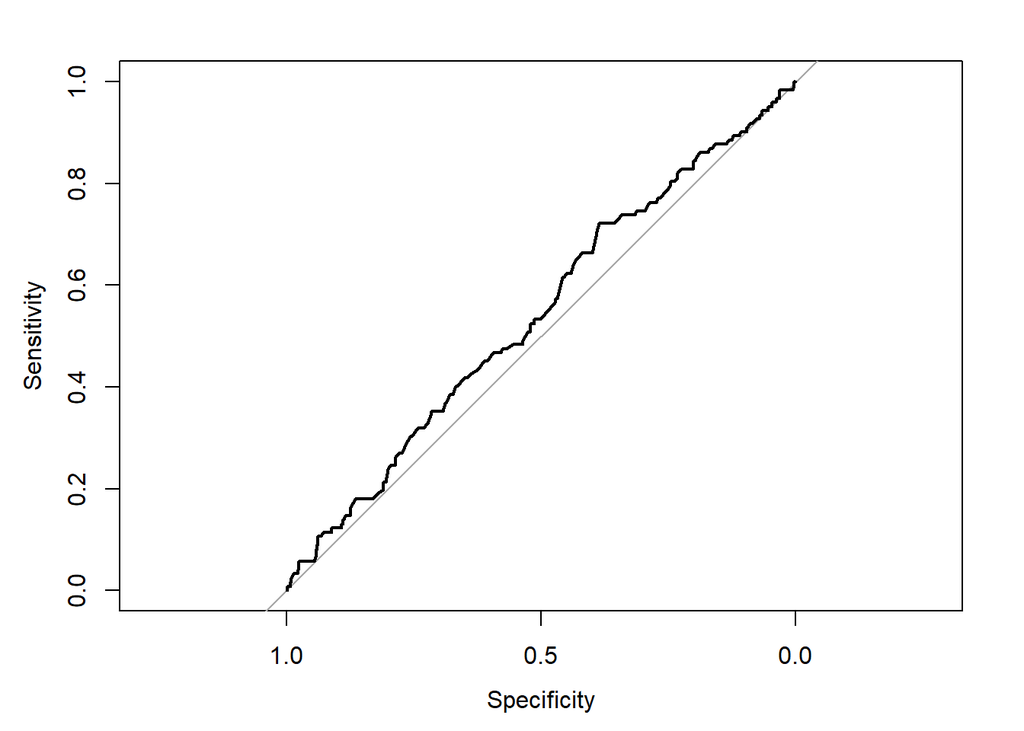

```r
plot(ROC1)
```

Ahora mediremos el poder predictivo de cada una de las varaibles consideradas.

```r
# con pROC
ROC1 <- roc(Data_Reg_log$target~as.numeric(Data_Reg_log$edad))
print("Nivel predictibilidad de esta variable independiente sobre la variable dependiente es: ")
```

```
## [1] "Nivel predictibilidad de esta variable independiente sobre la variable dependiente es: "
```

```r
print(ROC1)
```

```
##
## Call:
## roc.formula(formula = Data_Reg_log$target ~ as.numeric(Data_Reg_log$edad))
##
## Data: as.numeric(Data_Reg_log$edad) in 530 controls (Data_Reg_log$target 0) < 122 cases (Data_Reg_log$target 1).
## Area under the curve: 0.5355
```

```r
print("Intervalo de confianza de la curva ROC")
```

```
## [1] "Intervalo de confianza de la curva ROC"
```

```r
print(ci.auc(ROC1))
```

```
## 95% CI: 0.48-0.591 (DeLong)
```

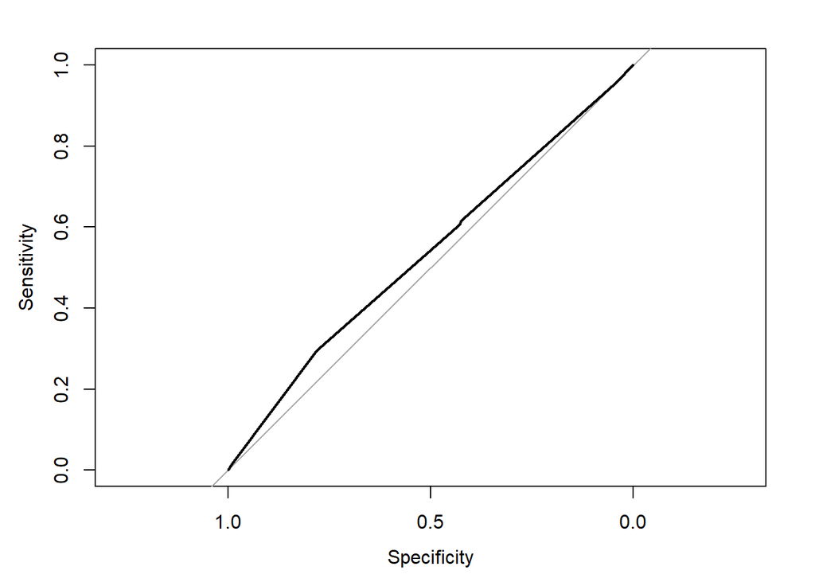

```r
plot(ROC1)
```

Ahora mediremos el poder predictivo de cada una de las varaibles consideradas.

```r
# con pROC
ROC1 <- roc(Data_Reg_log$target~as.numeric(Data_Reg_log$peso_kg))
print("Nivel predictibilidad de esta variable independiente sobre la variable dependiente es: ")
```

```
## [1] "Nivel predictibilidad de esta variable independiente sobre la variable dependiente es: "
```

```r
print(ROC1)
```

```
##
## Call:
## roc.formula(formula = Data_Reg_log$target ~ as.numeric(Data_Reg_log$peso_kg))
##
## Data: as.numeric(Data_Reg_log$peso_kg) in 530 controls (Data_Reg_log$target 0) < 122 cases (Data_Reg_log$target 1).
## Area under the curve: 0.7387
```

```r
print("Intervalo de confianza de la curva ROC")
```

```
## [1] "Intervalo de confianza de la curva ROC"
```

```r
print(ci.auc(ROC1))
```

```
## 95% CI: 0.6885-0.7889 (DeLong)
```

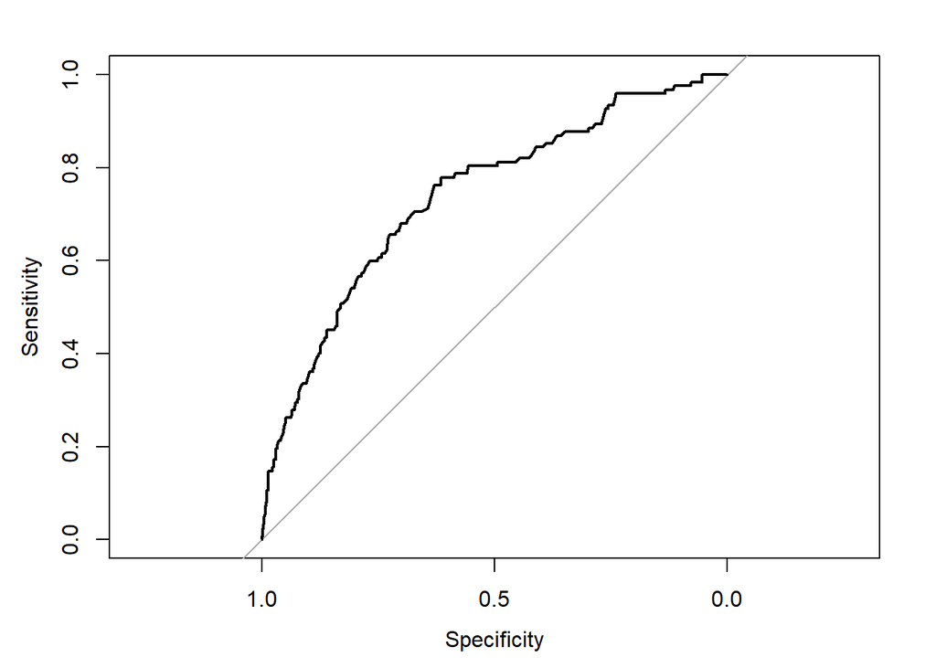

```r
plot(ROC1)
```

Ahora mediremos el poder predictivo de cada una de las varaibles consideradas.

```r
# con pROC
ROC1 <- roc(Data_Reg_log$target~as.numeric(Data_Reg_log$circun_cuello))
print("Nivel predictibilidad de esta variable independiente sobre la variable dependiente es: ")
```

```
## [1] "Nivel predictibilidad de esta variable independiente sobre la variable dependiente es: "
```

```r
print(ROC1)
```

```
##
## Call:
## roc.formula(formula = Data_Reg_log$target ~ as.numeric(Data_Reg_log$circun_cuello))
##
## Data: as.numeric(Data_Reg_log$circun_cuello) in 530 controls (Data_Reg_log$target 0) < 122 cases (Data_Reg_log$target 1).
## Area under the curve: 0.7581
```

```r
print("Intervalo de confianza de la curva ROC")
```

```
## [1] "Intervalo de confianza de la curva ROC"
```

```r
print(ci.auc(ROC1))
```

```
## 95% CI: 0.7089-0.8073 (DeLong)
```

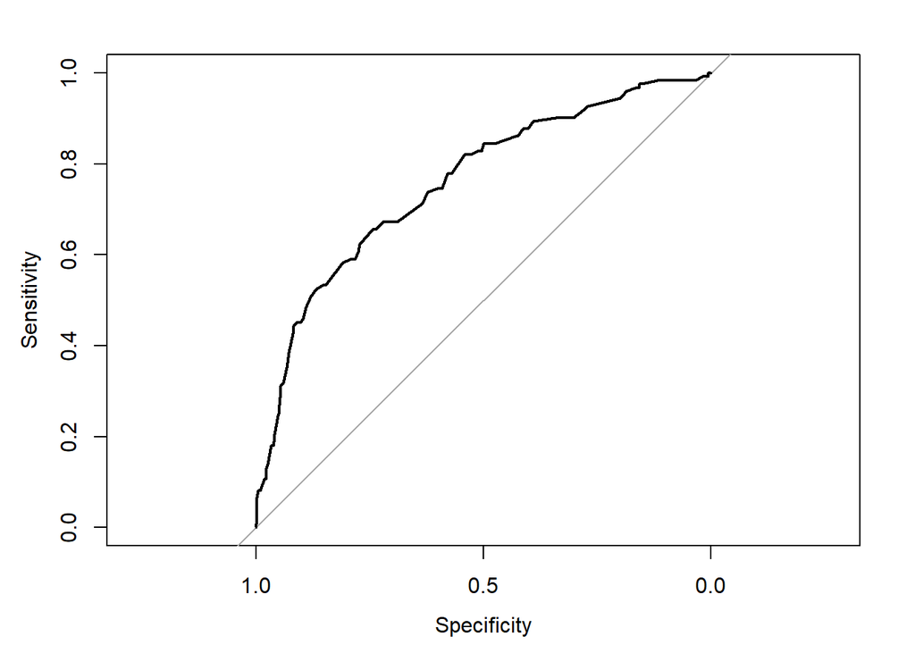

```r
plot(ROC1)
```

Ahora mediremos el poder predictivo de cada una de las varaibles consideradas.

```r
# con pROC
ROC1 <- roc(Data_Reg_log$target~as.numeric(Data_Reg_log$IMC))
print("Nivel predictibilidad de esta variable independiente sobre la variable dependiente es: ")
```

```
## [1] "Nivel predictibilidad de esta variable independiente sobre la variable dependiente es: "
```

```r
print(ROC1)
```

```
##
## Call:
## roc.formula(formula = Data_Reg_log$target ~ as.numeric(Data_Reg_log$IMC))
##
## Data: as.numeric(Data_Reg_log$IMC) in 530 controls (Data_Reg_log$target 0) < 122 cases (Data_Reg_log$target 1).
## Area under the curve: 0.783
```

```r
print("Intervalo de confianza de la curva ROC")
```

```
## [1] "Intervalo de confianza de la curva ROC"
```

```r
print(ci.auc(ROC1))
```

```
## 95% CI: 0.736-0.83 (DeLong)
```

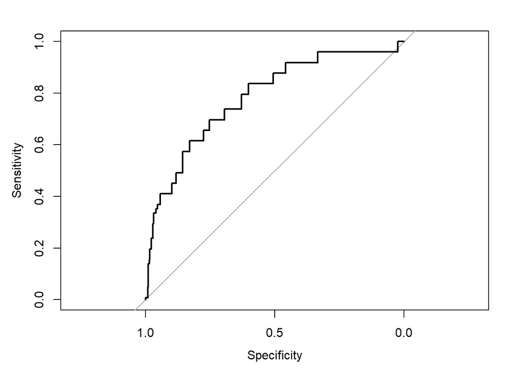

```r
plot(ROC1)
```

```r
# Observamos esta variable puede predecir a la variable dependiente
```

```r
# con pROC
ROC1 <- roc(Data_Reg_log$target~as.numeric(Data_Reg_log$circun_cintura))
print("Nivel predictibilidad de esta variable independiente sobre la variable dependiente es: ")
```

```
## [1] "Nivel predictibilidad de esta variable independiente sobre la variable dependiente es: "
```